# SELEX source data for manuscript figures

# Supplementary Figure 9

Drosophila and human HOX-cofactor logos.

**Figure S9 (logo components)**

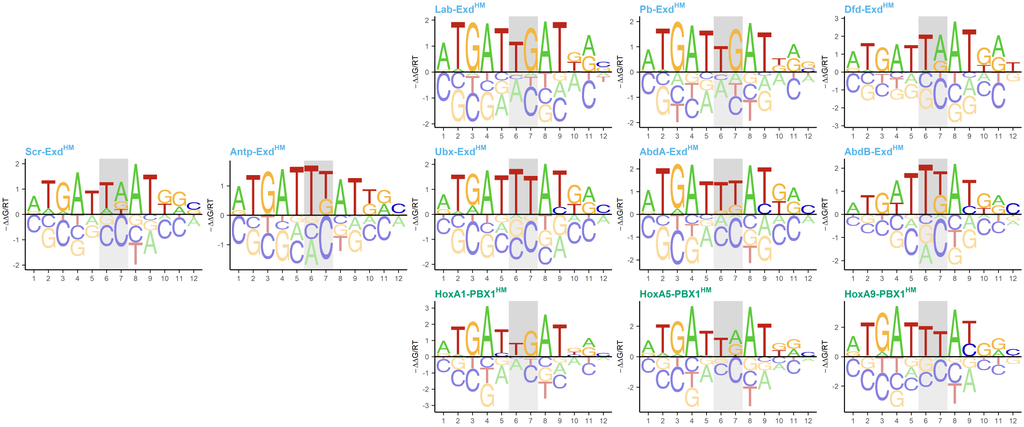

# Supplementary Figure 10

Drosophila HOX-Exd 12-mer clustering.

**Figure S10b**

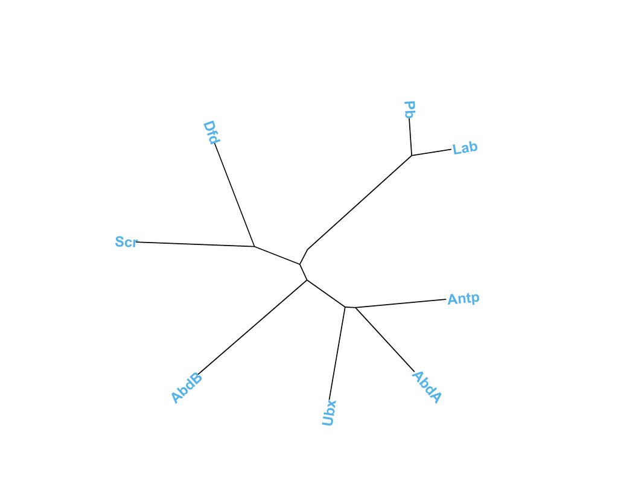

**Figure S10c**

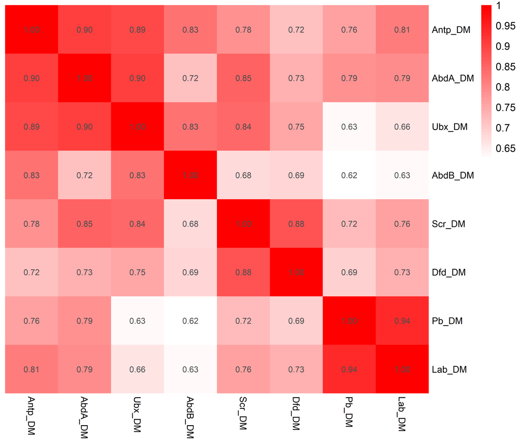

# Supplementary Figure 11

Nematostella HOX monomer motifs and clustering.

**Figure S11b**

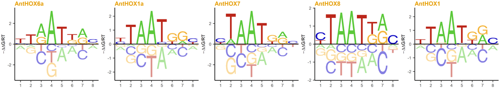

**Figure S11c**

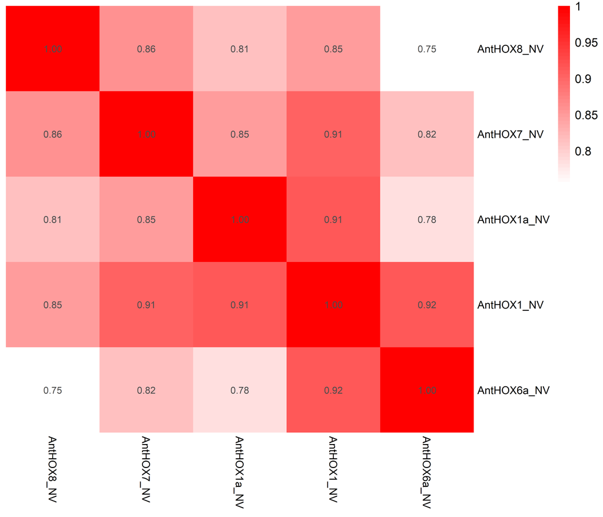

# Supplementary Figure 12

Synthetic-affinity comparisons used to contrast monomer and HOX-PBX binding relationships.

**Figure S12a-k**

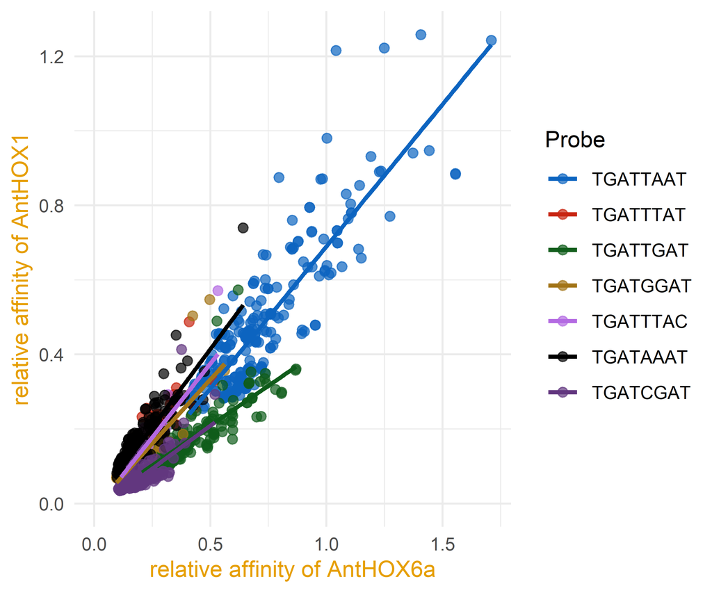

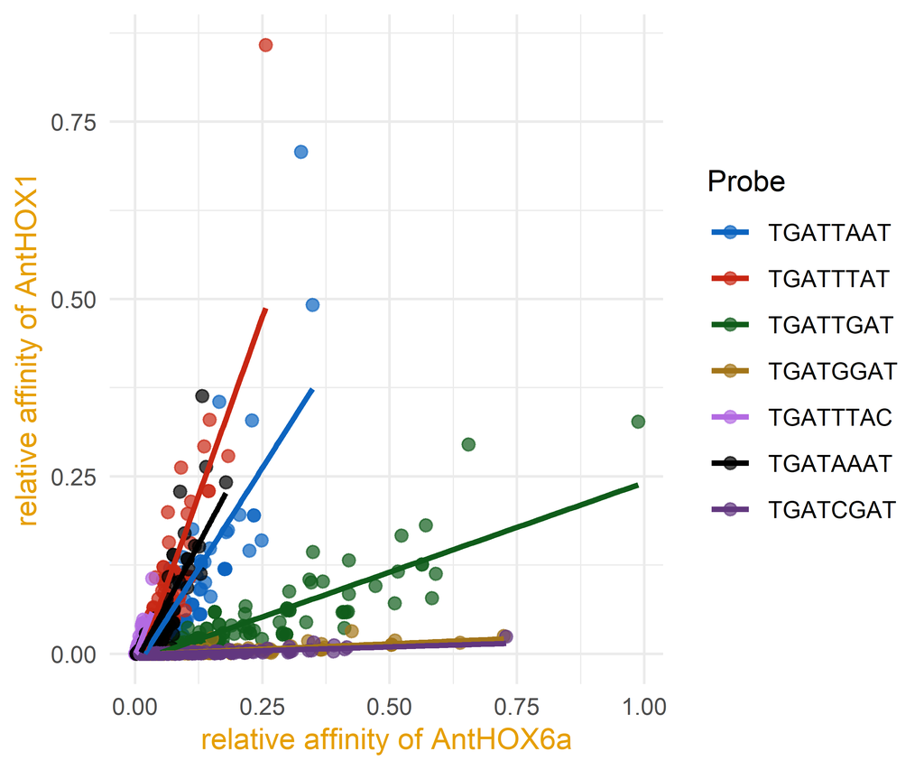

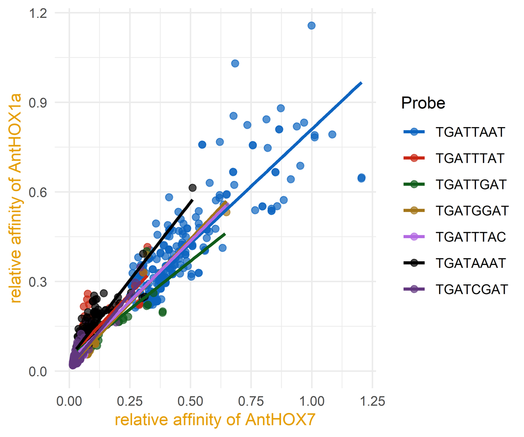

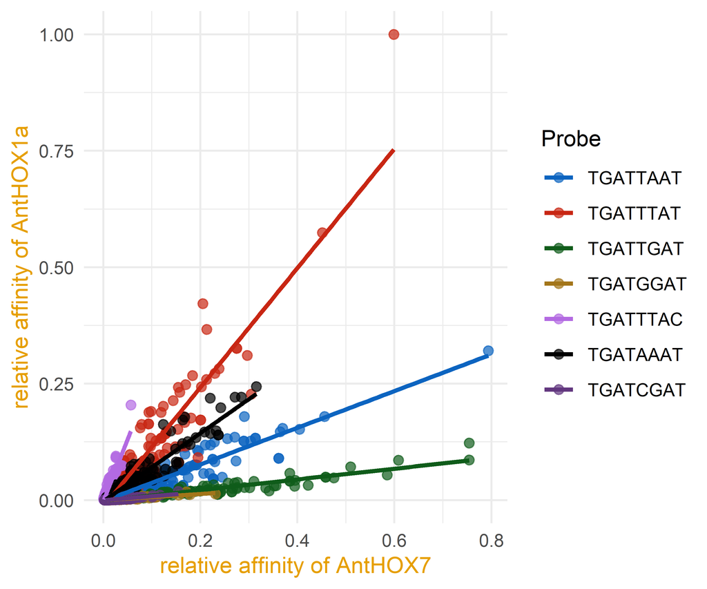

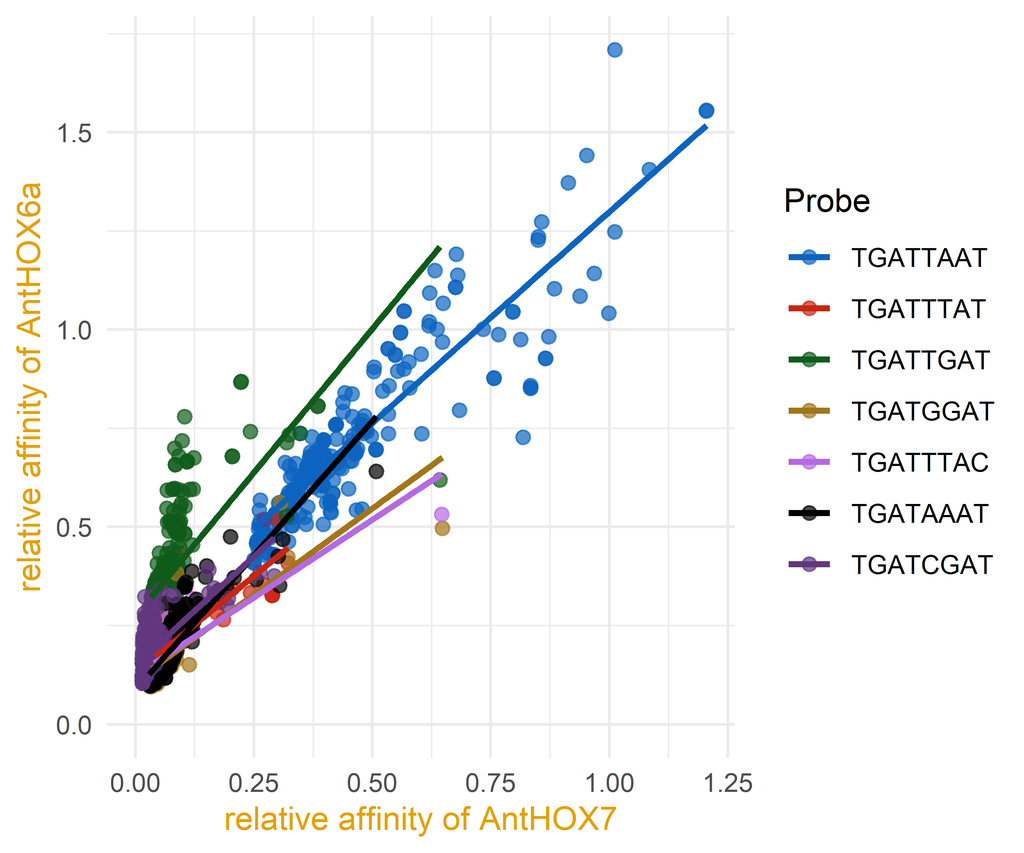

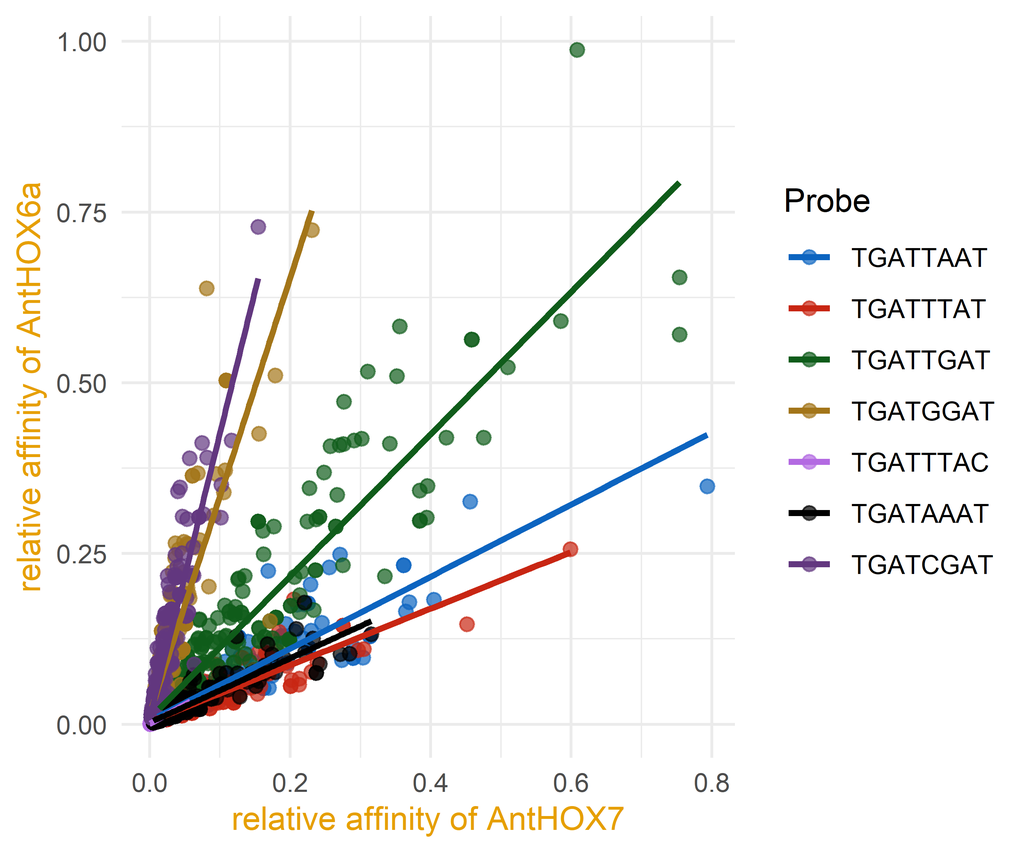

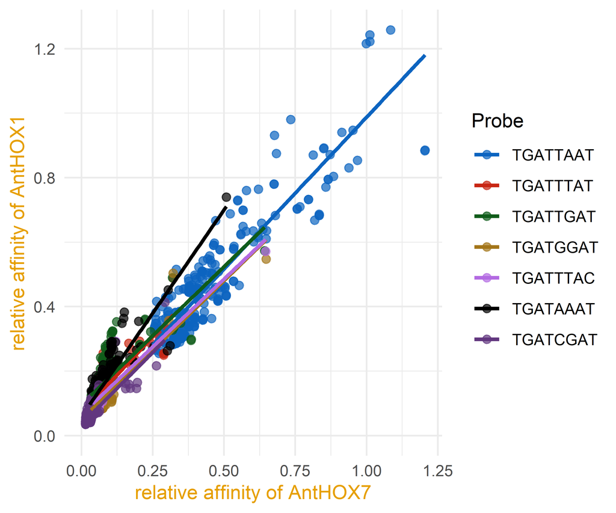

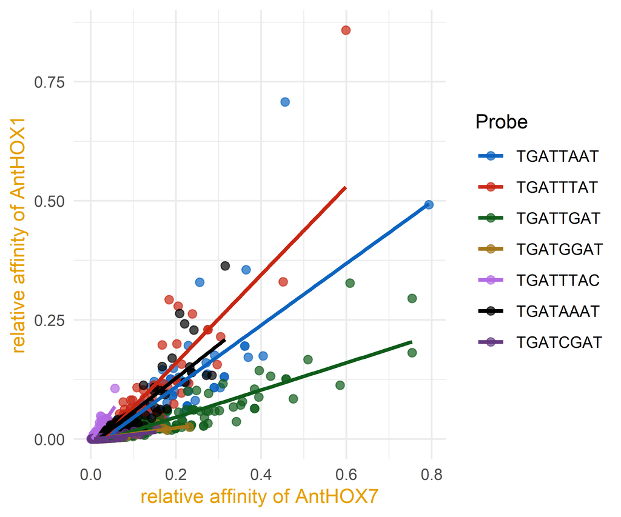

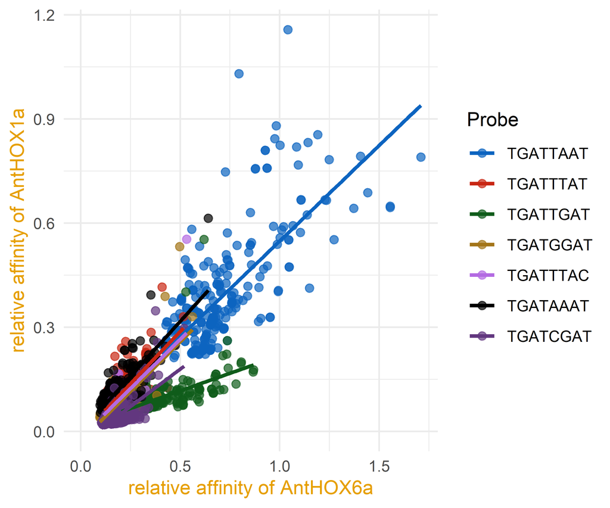

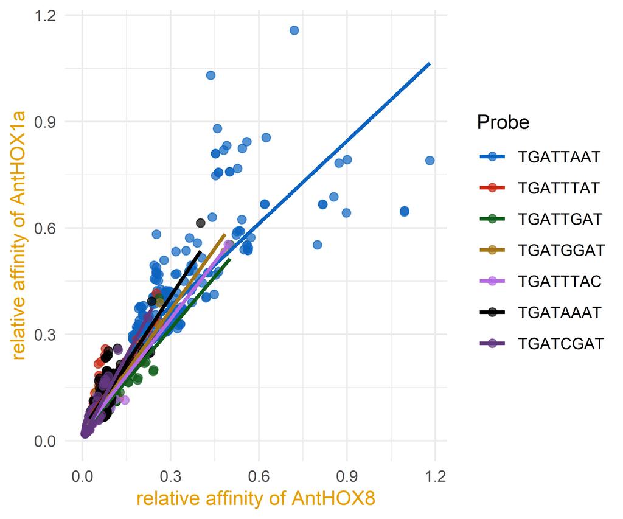

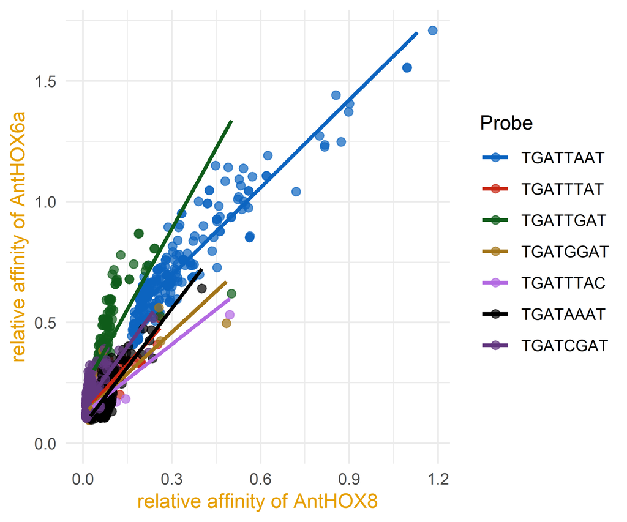

# Supplementary Figure 13

Oral-aboral class comparisons in Nematostella and Drosophila.

**Figure S13a-b**

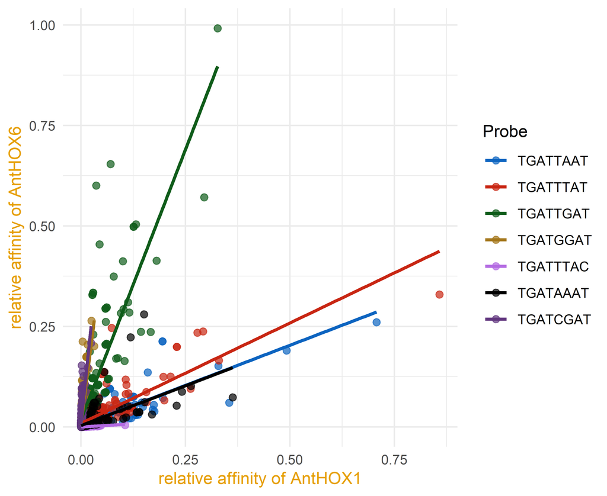

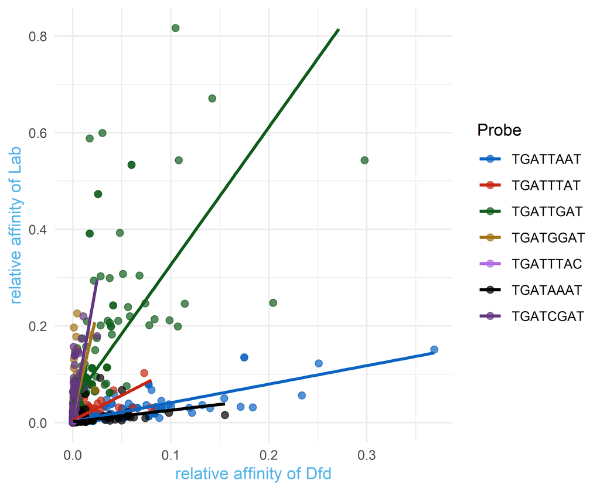

# Supplementary Figure 14

Replicate logos included in the manuscript reproducibility panel.

**Figure S14a-e**

[figure not shown]

# Supplementary Figure 15

Clustering of quality-controlled 12-mer replicate signatures with Drosophila and human reference models.

**Figure S15a**

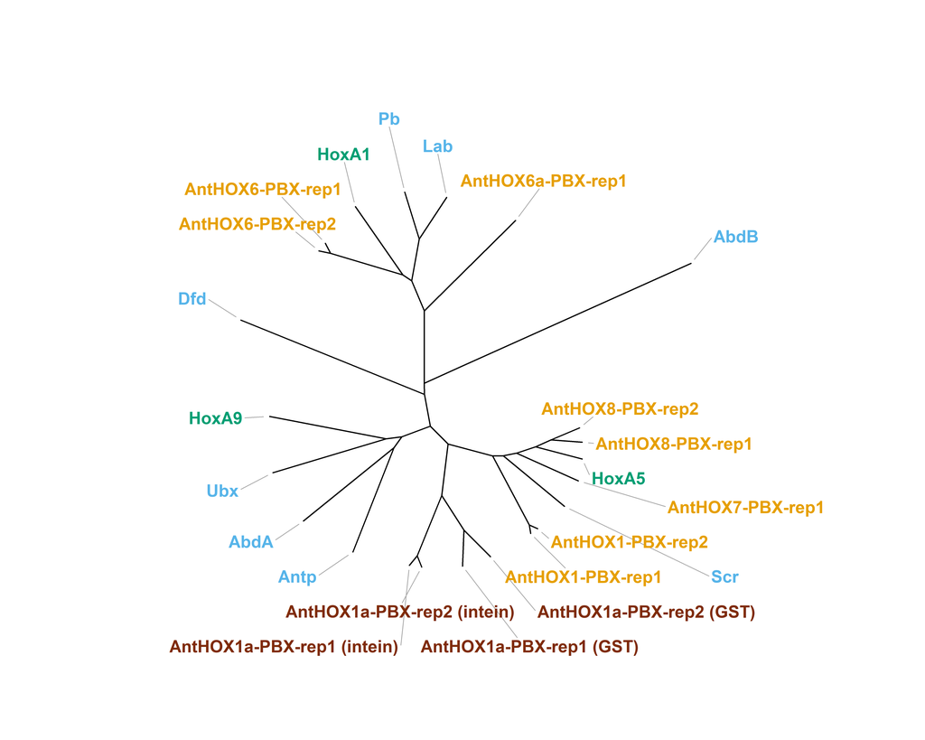

**Figure S15b**

[figure not shown]

# Supplementary Figure 16

Clustering of quality-controlled HOX-PBX 8-mer replicate signatures.

**Figure S16a**

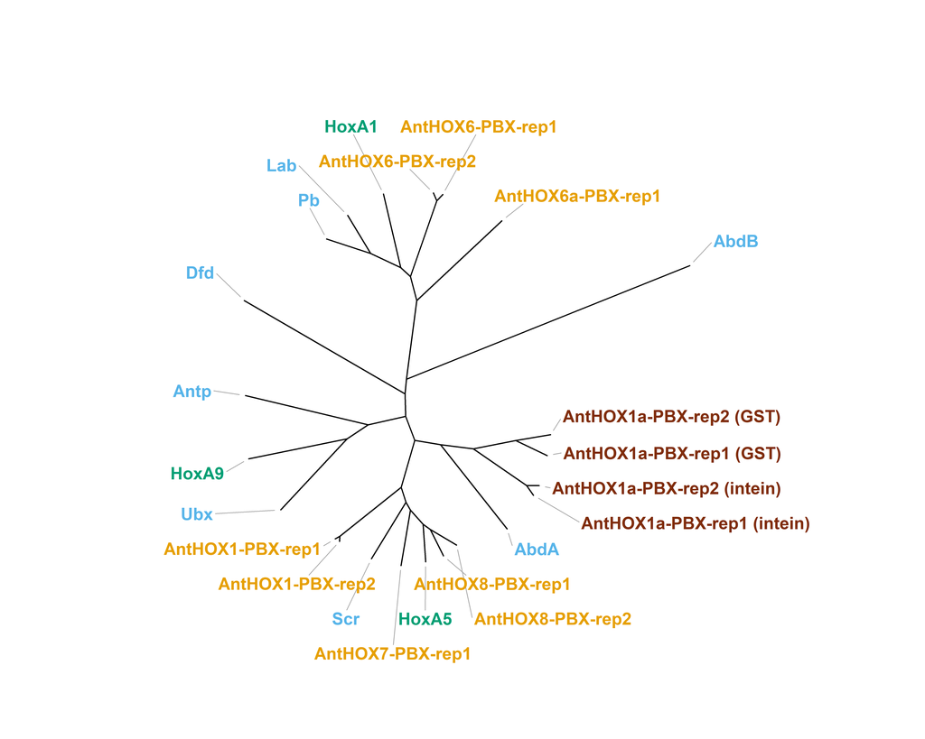

**Figure S16b**

[figure not shown]

# Supplementary Figure 17

Eight-mer clustering of the intein AntHOX1a replicate pair, the AntHOX1, AntHOX6 and AntHOX8 replicate pairs, and one dataset each for AntHOX6a and AntHOX7, together with human and Drosophila references.

**Figure S17a**

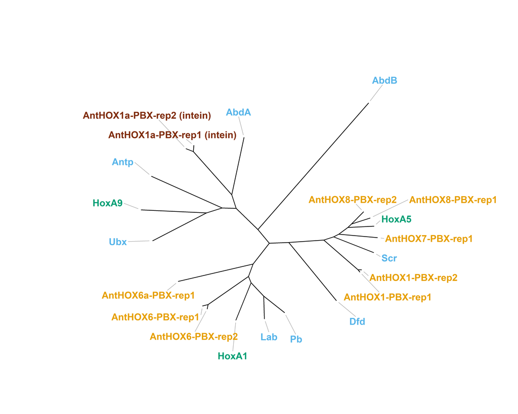

**Figure S17b**

[figure not shown]

# Supplementary Figure 18

Clustering of quality-controlled HOX 4-mer replicate signatures.

**Figure S18a**

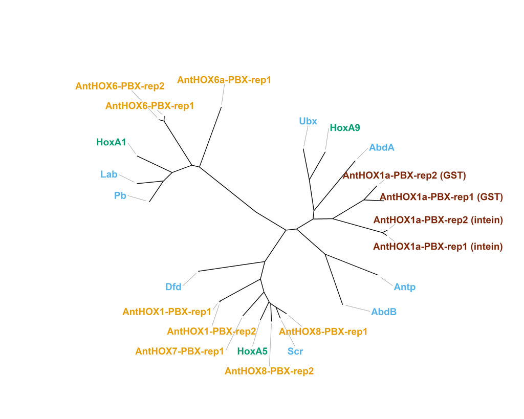

**Figure S18b**

[figure not shown]

# Supplementary Figure 19

Clustering of Nematostella replicate signatures across the complete 12-mer.

**Figure S19a**

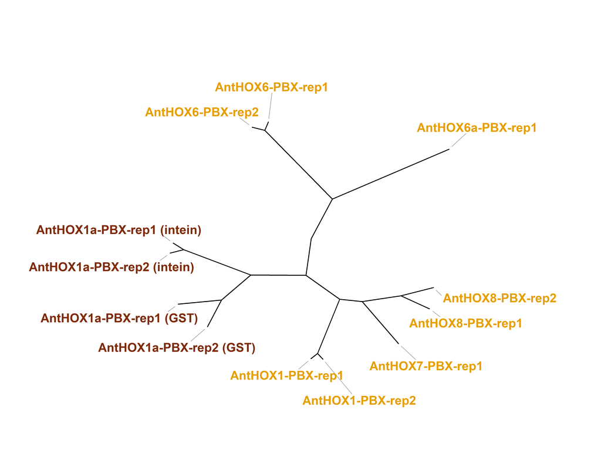

**Figure S19b**

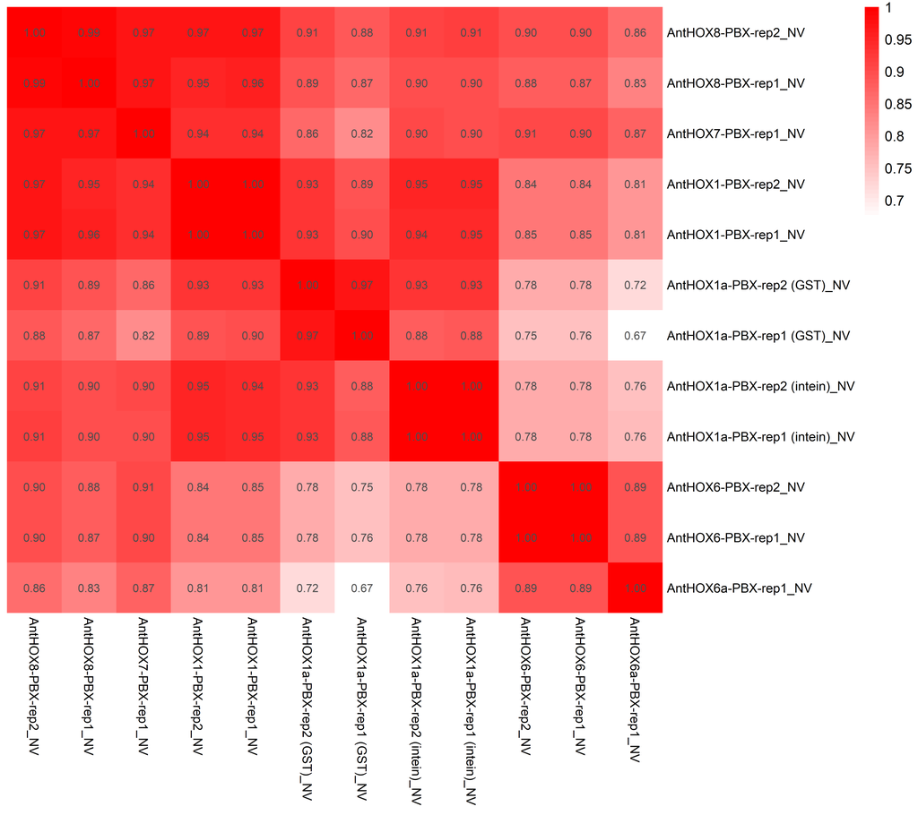

# Source data

## Replicate discrepancy

Each full 12-position motif has a 36-coordinate tetrahedron signature. Replicate differences use the complete signatures of four pairs: AntHOX1-PBX, AntHOX1a-PBX (intein), AntHOX6-PBX and AntHOX8-PBX. The AntHOX1a GST pair is not part of this estimate.

The plane defined by the full 12-position human HOXA1, HOXA5 and HOXA9 signatures has orthonormal basis vectors u<sub>1</sub> and u<sub>2</sub>, each with 36 coordinates. For each pair, the full difference vector Δ<sub>i</sub> is projected onto this plane, giving the length d<sub>i</sub> = √[(Δ<sub>i</sub> · u<sub>1</sub>)<sup>2</sup> + (Δ<sub>i</sub> · u<sub>2</sub>)<sup>2</sup>]. All 12 positions are retained for this calculation in every panel. The common bar half-width is the mean of d<sub>1</sub>, d<sub>2</sub>, d<sub>3</sub> and d<sub>4</sub>, and the total horizontal or vertical bar length is twice this mean.

The position-7 triangle and the 12-mer, 8-mer and 4-mer projections display this shared three-HOX-plane replicate discrepancy for all Nematostella points. Point coordinates use the positions and reference plane specified for each panel. The source tables include the 36-coordinate error-plane basis, full replicate differences and their projected lengths.

| Replicate 1 | Replicate 2 | Projected Euclidean distance |
| --- | --- | --- |
| AntHOX1-PBX-rep1 | AntHOX1-PBX-rep2 | 0.0098459 |
| AntHOX1a-PBX-rep1 (intein) | AntHOX1a-PBX-rep2 (intein) | 0.0113708 |
| AntHOX6-PBX-rep1 | AntHOX6-PBX-rep2 | 0.0237321 |
| AntHOX8-PBX-rep1 | AntHOX8-PBX-rep2 | 0.1411488 |

| Panel | Bar half-width | Total bar length |
| --- | --- | --- |
| Figure 2b | 0.0465244 | 0.0930488 |
| Figure S2a | 0.0465244 | 0.0930488 |
| Figure S2b | 0.0465244 | 0.0930488 |
| Figure S2c | 0.0465244 | 0.0930488 |

## Projection coordinates

Coordinates are expressed in orthonormal bases of the planes used for the corresponding panels. CSV tables contain the coordinates, selected features, replicate identities and error-bar values. Newick trees and pairwise R-squared matrices accompany the clustering panels. Tree-label tables link Newick identifiers to the labels displayed in each figure.

### Figure 2b

| HOX model | x | y |
| --- | --- | --- |
| AbdA | 1.249391 | 1.324834 |
| AbdB | 1.072931 | 1.138388 |
| AntHOX1 | 1.709283 | 0.917260 |
| AntHOX1a | 1.695257 | 1.467669 |
| AntHOX6 | 0.801840 | 0.603319 |
| AntHOX6a | 0.965217 | 0.399023 |
| AntHOX7 | 1.310314 | 0.615581 |
| AntHOX8 | 1.606131 | 0.575602 |
| Antp | 1.227586 | 1.170278 |
| Dfd | 1.906094 | 0.267796 |
| HoxA1 | 0.569909 | 0.281616 |
| HoxA5 | 1.535094 | 0.498138 |
| HoxA9 | 1.381922 | 1.813929 |
| Lab | 0.511107 | 0.262001 |
| Pb | 0.459544 | 0.255626 |
| Scr | 1.642509 | 0.639324 |
| Ubx | 1.457059 | 1.734654 |

### Figure S2a

| HOX model | x | y |
| --- | --- | --- |
| AbdA | 1.042315 | 0.883264 |
| AbdB | 0.966708 | 0.945368 |
| AntHOX1 | 1.535876 | 0.397532 |
| AntHOX1a | 1.476052 | 0.769259 |
| AntHOX6 | 0.435962 | 0.162584 |
| AntHOX6a | 0.267176 | 0.045920 |
| AntHOX7 | 0.890526 | 0.082284 |
| AntHOX8 | 1.253561 | 0.054220 |
| Antp | 0.987235 | 0.789482 |
| Dfd | 1.556829 | -0.169484 |
| HoxA1 | 0.000000 | 0.000000 |
| HoxA5 | 1.158964 | 0.000000 |
| HoxA9 | 1.506722 | 1.690896 |
| Lab | 0.077529 | 0.112987 |
| Pb | -0.010120 | 0.177303 |
| Scr | 1.139632 | -0.040592 |
| Ubx | 1.411660 | 1.172249 |

### Figure S2b

| HOX model | x | y |
| --- | --- | --- |
| AbdA | 0.942049 | 0.922914 |
| AbdB | 0.899512 | 0.963678 |
| AntHOX1 | 1.455467 | 0.359097 |
| AntHOX1a | 1.406399 | 0.733865 |
| AntHOX6 | 0.425385 | 0.190344 |
| AntHOX6a | 0.205797 | 0.055126 |
| AntHOX7 | 0.846965 | 0.046324 |
| AntHOX8 | 1.184614 | 0.015518 |
| Antp | 0.923388 | 0.875005 |
| Dfd | 1.504055 | -0.279639 |
| HoxA1 | 0.000000 | 0.000000 |
| HoxA5 | 1.112027 | 0.000000 |
| HoxA9 | 1.441434 | 1.599613 |
| Lab | 0.056828 | 0.139825 |
| Pb | -0.029062 | 0.223606 |
| Scr | 1.070919 | -0.029648 |
| Ubx | 1.348523 | 1.223992 |

### Figure S2c

| HOX model | x | y |
| --- | --- | --- |
| AbdA | 0.935432 | 0.959039 |
| AbdB | 0.923627 | 1.082350 |
| AntHOX1 | 1.412784 | 0.347826 |
| AntHOX1a | 1.412859 | 0.807574 |
| AntHOX6 | 0.382158 | 0.136814 |
| AntHOX6a | 0.194611 | 0.073704 |
| AntHOX7 | 0.875178 | 0.147342 |
| AntHOX8 | 1.187124 | 0.076011 |
| Antp | 0.923308 | 0.929120 |
| Dfd | 1.525072 | -0.219174 |
| HoxA1 | 0.000000 | 0.000000 |
| HoxA5 | 1.101099 | 0.000000 |
| HoxA9 | 1.372767 | 1.536264 |
| Lab | 0.032521 | 0.083397 |
| Pb | -0.044442 | 0.179914 |
| Scr | 1.142835 | 0.167307 |
| Ubx | 1.350004 | 1.337221 |

## Affinity comparisons

CSV tables provide the seeded DNA sequences, separate forward and reverse-complement affinities and their sums for every model used in the scatter plots. Coordinates, sequence identities and fitted-line coefficients for all 28 scatter panels accompany the model-level affinity and coefficient tables.

## Software environment

The analysis uses R and the packages listed below.

| Software | Version |
| --- | --- |
| R | 4.3.1 |
| FamilyCode | 1.0.1 |
| pheatmap | 1.0.13 |
| ggplot2 | 3.5.2 |
| dplyr | 1.1.4 |
| ape | 5.8.1 |
| phangorn | 2.12.1 |
| ggtree | 3.8.2 |
| Rtsne | 0.17 |
| ggrepel | 0.9.6 |
| EnvStats | 3.1.0 |
| stringr | 1.5.1 |
| digest | 0.6.33 |
| rmarkdown | 2.29 |
| knitr | 1.50 |